# R Notebook

## Exercise: least squares regression

## ────────────────────────────────────────

## Use the /states.rds/ data set. Fit a model predicting energy consumed

## per capita (energy) from the percentage of residents living in

## metropolitan areas (metro). Be sure to

## 1. Examine/plot the data before fitting the model

## 2. Print and interpret the model `summary' ## 3.`plot’ the model to look for deviations from modeling assumptions

## Select one or more additional predictors to add to your model and

## repeat steps 1-3. Is this model significantly better than the model

## with /metro/ as the only predictor?

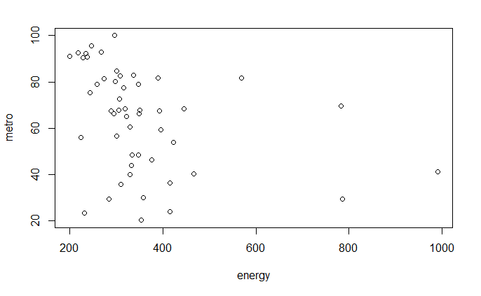

```r
sts.eng.met <- subset(states.data, select = c("energy", "metro"))
plot(sts.eng.met)
```

```r
states.info1<- lm(energy~ metro, data = states.data)
summary(states.info1)
```

```
Call:
lm(formula = energy ~ metro, data = states.data)

Residuals:
    Min      1Q  Median      3Q     Max
-215.51  -64.54  -30.87   18.71  583.97

Coefficients:
            Estimate Std. Error t value Pr(>|t|)
(Intercept) 501.0292    61.8136   8.105 1.53e-10 ***
metro        -2.2871     0.9139  -2.503   0.0158 *
---
Signif. codes:  0 ‘***’ 0.001 ‘**’ 0.01 ‘*’ 0.05 ‘.’ 0.1 ‘ ’ 1

Residual standard error: 140.2 on 48 degrees of freedom
  (1 observation deleted due to missingness)
Multiple R-squared:  0.1154,    Adjusted R-squared:  0.097
F-statistic: 6.263 on 1 and 48 DF,  p-value: 0.01578
```

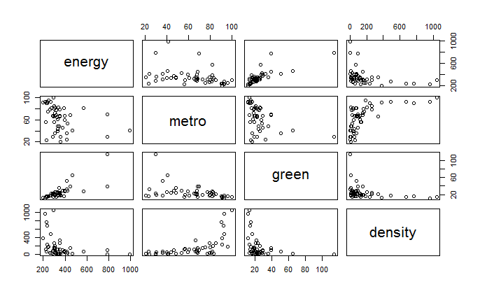

```r
sts.eng.met.gre.des<-subset(states.data,select = c("energy","metro",
                            "green","density"))
plot(sts.eng.met.gre.des)
```

```r
states.info2<-lm(energy~metro+green+density,data=states.data)
summary(states.info2)
```

```
Call:
lm(formula = energy ~ metro + green + density, data = states.data)

Residuals:
   Min     1Q Median     3Q    Max
-93.14 -42.25 -13.45  21.59 354.38

Coefficients:
             Estimate Std. Error t value Pr(>|t|)
(Intercept) 187.19154   48.40117   3.868 0.000359 ***
metro         0.54741    0.64924   0.843 0.403702
green         5.39192    0.73233   7.363 3.37e-09 ***
density      -0.08401    0.05742  -1.463 0.150539
---
Signif. codes:  0 ‘***’ 0.001 ‘**’ 0.01 ‘*’ 0.05 ‘.’ 0.1 ‘ ’ 1

Residual standard error: 75.22 on 44 degrees of freedom
  (3 observations deleted due to missingness)
Multiple R-squared:  0.6127,    Adjusted R-squared:  0.5863
F-statistic:  23.2 on 3 and 44 DF,  p-value: 3.688e-09
```

The model was significantly different when adding green as a predictor, the r- squared and Adjusted R-squared increased dramatically.

## Regression with categorical predictors

## ──────────────────────────────────────────

## Let’s try to predict SAT scores from region, a categorical variable.

## Note that you must make sure R does not think your categorical

## variable is numeric.

# make sure R knows region is categorical

## Again, *make sure to tell R which variables are categorical by ## converting them to factors!*

## Setting factor reference groups and contrasts

## ─────────────────────────────────────────────────

## In the previous example we use the default contrasts for region. The

## default in R is treatment contrasts, with the first level as the

## reference. We can change the reference group or use another coding

## scheme using the `C’ function.

# print default contrasts

## See also `?contrasts',`?contr.treatment’, and `?relevel’.

```r
 #Add the interaction to the model
sat.expense.by.percent <- lm(csat ~ expense*income,
                             data=states.data)
 coef(summary(sat.expense.by.percent)) # show regression coefficients table
```

```
                    Estimate   Std. Error   t value     Pr(>|t|)
(Intercept)     1.380364e+03 1.720863e+02  8.021351 2.367069e-10
expense        -6.384067e-02 3.270087e-02 -1.952262 5.687837e-02
income         -1.049785e+01 4.991463e+00 -2.103161 4.083253e-02
expense:income  1.384647e-03 8.635529e-04  1.603431 1.155395e-01
```

```r
# make sure R knows region is categorical
str(states.data$region)
```

```
 Factor w/ 4 levels "West","N. East",..: 3 1 1 3 1 1 2 3 NA 3 ...
```

```r
states.data$region <- factor(states.data$region)
#Add region to the model
sat.region <- lm(csat ~ region,
                 data=states.data)
#Show the results
coef(summary(sat.region)) # show regression coefficients table
```

```
               Estimate Std. Error    t value     Pr(>|t|)
(Intercept)   946.30769   14.79582 63.9577807 1.352577e-46
regionN. East -56.75214   23.13285 -2.4533141 1.800383e-02
regionSouth   -16.30769   19.91948 -0.8186806 4.171898e-01
regionMidwest  63.77564   21.35592  2.9863209 4.514152e-03
```

```r
anova(sat.region) # show ANOVA table
```

```
Analysis of Variance Table

Response: csat
          Df Sum Sq Mean Sq F value    Pr(>F)
region     3  82049 27349.8  9.6102 4.859e-05 ***
Residuals 46 130912  2845.9
---
Signif. codes:  0 ‘***’ 0.001 ‘**’ 0.01 ‘*’ 0.05 ‘.’ 0.1 ‘ ’ 1
```

```r
# print default contrasts
contrasts(states.data$region)
```

```
        N. East South Midwest
West          0     0       0
N. East       1     0       0
South         0     1       0
Midwest       0     0       1
```

```r
# change the reference group
coef(summary(lm(csat ~ C(region, base=4),
                data=states.data)))
```

```
                       Estimate Std. Error   t value     Pr(>|t|)
(Intercept)          1010.08333   15.39998 65.589930 4.296307e-47
C(region, base = 4)1  -63.77564   21.35592 -2.986321 4.514152e-03
C(region, base = 4)2 -120.52778   23.52385 -5.123641 5.798399e-06
C(region, base = 4)3  -80.08333   20.37225 -3.931000 2.826007e-04
```

```r
# change the coding scheme
coef(summary(lm(csat ~ C(region, contr.helmert),
                data=states.data)))
```

```
                            Estimate Std. Error     t value     Pr(>|t|)
(Intercept)               943.986645   7.706155 122.4977451 1.689670e-59
C(region, contr.helmert)1 -28.376068  11.566423  -2.4533141 1.800383e-02
C(region, contr.helmert)2   4.022792   5.884552   0.6836191 4.976450e-01
C(region, contr.helmert)3  22.032229   4.446777   4.9546509 1.023364e-05
```

## Exercise: interactions and factors

## ────────────────────────────────────────

## Use the states data set.

## 1. Add on to the regression equation that you created in exercise 1 by

## generating an interaction term and testing the interaction.

## 2. Try adding region to the model. Are there significant differences

## across the four regions?

```r
states.info3<- lm(energy~ metro*college, data = states.data)
 coef(summary(states.info3)) # show regression coefficients table
```

```
                 Estimate  Std. Error    t value  Pr(>|t|)
(Intercept)   173.2208505 344.2305571  0.5032117 0.6172166
metro           3.8667119   5.1269950  0.7541868 0.4545807
college        15.9302000  17.7611168  0.8969143 0.3744349
metro:college  -0.2929545   0.2503469 -1.1701941 0.2479500
```

```r
# make sure R knows region is categorical
str(states.data$region)
```

```
 Factor w/ 4 levels "West","N. East",..: 3 1 1 3 1 1 2 3 NA 3 ...
```

```r
#Add region to the model
met.region <- lm(energy
                 ~ region,
                 data=states.data)
#Show the results
coef(summary(met.region)) # show regression coefficients table
```

```
                Estimate Std. Error    t value     Pr(>|t|)
(Intercept)    405.61538   39.23196 10.3389019 1.395176e-13
regionN. East -156.50427   61.33807 -2.5515032 1.411486e-02
regionSouth    -25.49038   52.81764 -0.4826112 6.316606e-01
regionMidwest  -61.61538   56.62646 -1.0881024 2.822182e-01
```

```r
anova(met.region) # show ANOVA table
```

```
Analysis of Variance Table

Response: energy
          Df Sum Sq Mean Sq F value  Pr(>F)
region     3 145757   48586  2.4282 0.07737 .
Residuals 46 920410   20009
---
Signif. codes:  0 ‘***’ 0.001 ‘**’ 0.01 ‘*’ 0.05 ‘.’ 0.1 ‘ ’ 1
```

```r
# print default contrasts
contrasts(states.data$region)
```

```
        N. East South Midwest
West          0     0       0
N. East       1     0       0
South         0     1       0
Midwest       0     0       1
```

```r
# change the reference group
coef(summary(lm(energy ~ C(region, base=4),
                data=states.data)))
```

```
                      Estimate Std. Error    t value     Pr(>|t|)
(Intercept)          344.00000   40.83392  8.4243691 7.058813e-11
C(region, base = 4)1  61.61538   56.62646  1.0881024 2.822182e-01
C(region, base = 4)2 -94.88889   62.37484 -1.5212686 1.350374e-01
C(region, base = 4)3  36.12500   54.01820  0.6687561 5.069935e-01
```

```r
# change the coding scheme
coef(summary(lm(energy ~ C(region, contr.helmert),
                data=states.data)))
```

```
                             Estimate Std. Error     t value     Pr(>|t|)
(Intercept)               344.7128739   20.43331 16.87014156 2.504367e-21
C(region, contr.helmert)1 -78.2521368   30.66903 -2.55150316 1.411486e-02
C(region, contr.helmert)2  17.5872507   15.60323  1.12715468 2.655225e-01
C(region, contr.helmert)3  -0.2376246   11.79088 -0.02015325 9.840083e-01
```